# Demonstration of Unsupervised Methods

JAS

# Demonstration of Unsupervised Methods

We will be using the following dataset to demonstrate clustering methods.

- Simulated data that we will use to represent clinical phenotypic data on COPD extracted from an EHR system.
  - Data Citation: Ultsch, A.: Clustering with SOM: U*C, In Proc. Workshop on Self-Organizing Maps, Paris, France, (2005) , pp. 75-82

### Load Packages Needed for Both Demonstrations

```r
library(stats)
library(factoextra)
library(cluster)
```

### Demonstration of Clustering Analysis

In this demonstration, we will attempt to uncover phenotypic subtypes within clinical data of Chronic Obstructive Pulmonary Disease (COPD). COPD is defined as airflow limitation that is not fully reversible. This is a very broad definition, and it suspected that there are a number of distinct phenotypes within the broader term of COPD. Identifying these subtypes can allow researchers to conduct more targeted investigations of COPD, uncovering mechanisms and risk factors for the different subtypes. This demonstration is loosely based on the work performed by Cho et al. Respiratory Research 2010; 11:30. The data are not the same. Please note that for practical reasons, we are using a small dataset with only 3 variables and 212 patient records. But, this same procedure could be repeated with a larger number of variables and/or records.

For this demonstration, the three variables in our dataset are: 1. post-bronchodilator FEV1 percent predicted 2. percent bronchodilator responsiveness 3. airway wall thickness

### Step 1: Load data and prepare for analysis

```r
copd.data<-read.delim("C:/Users/js5406/OneDrive - cumc.columbia.edu/EPIC Course/Hepta.lrn", header=FALSE)

#copd.data<-read.delim("Data/Hepta.lrn", header=FALSE)

copd.data<-copd.data[,2:4]

var.names<-c("pb_FEV1_pctpred", "pct_br_resp", "awt")
colnames(copd.data)<-var.names

#Omitting all missing data, if any
copd.data.nomiss<-na.omit(copd.data)

#Check means and SDs to determine if scaling is necessary
colMeans(copd.data.nomiss, na.rm=TRUE)
```

```
## pb_FEV1_pctpred     pct_br_resp             awt
##      0.01541768      0.03418329     -0.03562636
```

```r
apply(copd.data.nomiss, 2, sd, na.rm=TRUE)
```

```
## pb_FEV1_pctpred     pct_br_resp             awt
##        1.647716        1.670505        1.628822
```

### Step 2: Conduct a clustering analysis using k-means clustering

We can use the kmeans function in order to identify clusters within the data, based on the three variables. Option nstart indicates the number of initial random configurations that are tried as the algorithm can be sensitive to the intial seeding of the means. So nstart of 25 translates to kmeans generating 25 initial configurations and then reporting the best one.

```r
set.seed(100)
clusters<-kmeans(copd.data.nomiss, 5, nstart=25)
str(clusters)
```

```
## List of 9
##  $ cluster     : Named int [1:212] 2 2 2 2 2 2 2 2 2 2 ...
##   ..- attr(*, "names")= chr [1:212] "1" "2" "3" "4" ...
##  $ centers     : num [1:5, 1:3] 2.9995 -0.9802 0.0227 0.14 -0.0473 ...
##   ..- attr(*, "dimnames")=List of 2
##   .. ..$ : chr [1:5] "1" "2" "3" "4" ...
##   .. ..$ : chr [1:3] "pb_FEV1_pctpred" "pct_br_resp" "awt"
##  $ totss       : num 1721
##  $ withinss    : num [1:5] 16.8 380.5 19 15.9 16.4
##  $ tot.withinss: num 449
##  $ betweenss   : num 1273
##  $ size        : int [1:5] 30 92 30 30 30
##  $ iter        : int 3
##  $ ifault      : int 0
##  - attr(*, "class")= chr "kmeans"
```

```r
#Number of observations per cluster
clusters$size
```

```
## [1] 30 92 30 30 30
```

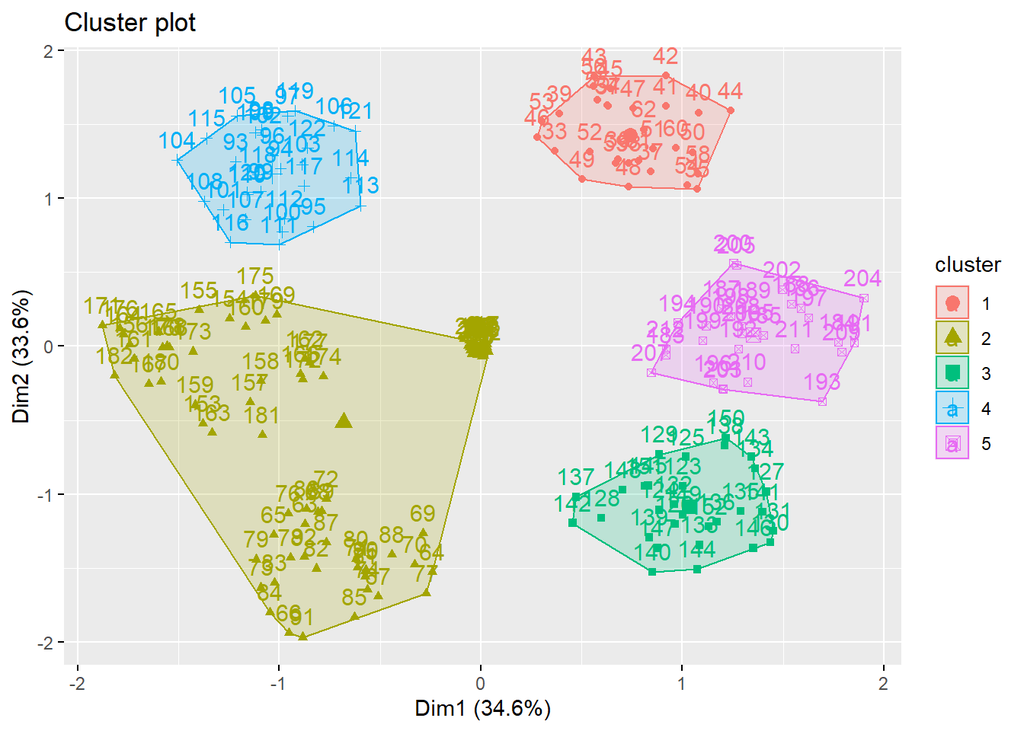

```r
#Visualize clusters
fviz_cluster(clusters, data=copd.data.nomiss)
```

```r
#Show the mean value of features within each cluster. Do they make substantive sense?
clusters$centers
```

```
##   pb_FEV1_pctpred  pct_br_resp        awt
## 1      2.99953830 -0.001130867 -0.1400596
## 2     -0.98022513  0.027156902  0.9679342
## 3      0.02271230 -2.968135967 -0.1117746
## 4      0.13998693  3.081746967  0.0745050
## 5     -0.04726217  0.045800633 -3.0427619
```

```r
#Conduct a gap_statistic analysis to determine optimal number of clusters
set.seed(100)
gap_stat<-clusGap(copd.data.nomiss, FUN=kmeans, nstart=25, K.max=9, B=5)
print(gap_stat, method="firstmax")
```

```
## Clustering Gap statistic ["clusGap"] from call:
## clusGap(x = copd.data.nomiss, FUNcluster = kmeans, K.max = 9,     B = 5, nstart = 25)
## B=5 simulated reference sets, k = 1..9; spaceH0="scaledPCA"
##  --> Number of clusters (method 'firstmax'): 7
##           logW   E.logW       gap     SE.sim
##  [1,] 5.282842 5.473538 0.1906954 0.02596558
##  [2,] 5.082621 5.290453 0.2078323 0.01986662
##  [3,] 4.914357 5.150136 0.2357785 0.02329605
##  [4,] 4.717145 5.025474 0.3083288 0.03036186
##  [5,] 4.462394 4.930348 0.4679541 0.02439212
##  [6,] 4.162681 4.842899 0.6802177 0.01949673
##  [7,] 3.825676 4.777790 0.9521137 0.02195004
##  [8,] 3.783336 4.716506 0.9331701 0.01897672
##  [9,] 3.748213 4.665759 0.9175466 0.01984780
```

```r
clusters.7<-kmeans(copd.data.nomiss, 7, nstart=25)
str(clusters.7)
```

```
## List of 9
##  $ cluster     : Named int [1:212] 4 4 4 4 4 4 4 4 4 4 ...
##   ..- attr(*, "names")= chr [1:212] "1" "2" "3" "4" ...
##  $ centers     : num [1:7, 1:3] 0.13999 -2.99519 -0.04726 -0.00424 0.02271 ...
##   ..- attr(*, "dimnames")=List of 2
##   .. ..$ : chr [1:7] "1" "2" "3" "4" ...
##   .. ..$ : chr [1:3] "pb_FEV1_pctpred" "pct_br_resp" "awt"
##  $ totss       : num 1721
##  $ withinss    : num [1:7] 15.943 18.76 16.418 0.187 18.966 ...
##  $ tot.withinss: num 106
##  $ betweenss   : num 1615
##  $ size        : int [1:7] 30 30 30 32 30 30 30
##  $ iter        : int 2
##  $ ifault      : int 0
##  - attr(*, "class")= chr "kmeans"
```

```r
clusters$centers
```

```
##   pb_FEV1_pctpred  pct_br_resp        awt
## 1      2.99953830 -0.001130867 -0.1400596
## 2     -0.98022513  0.027156902  0.9679342
## 3      0.02271230 -2.968135967 -0.1117746
## 4      0.13998693  3.081746967  0.0745050
## 5     -0.04726217  0.045800633 -3.0427619
```

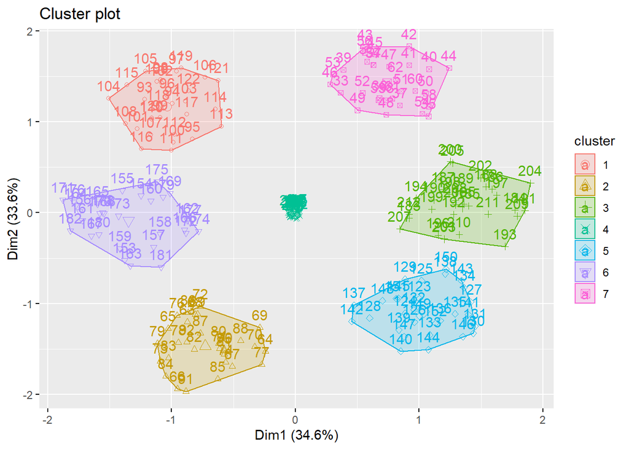

```r
fviz_cluster(clusters.7, data=copd.data.nomiss)
```

### Step 3: Conduct a hierarchical clustering analysis

Note there are different methods you can use to create your dissimilarity matrix. We are using complete linkage in this demonstration, which tends to produce more compact clusters.

hclust is from the stats package. It performs agglomerative clustering.

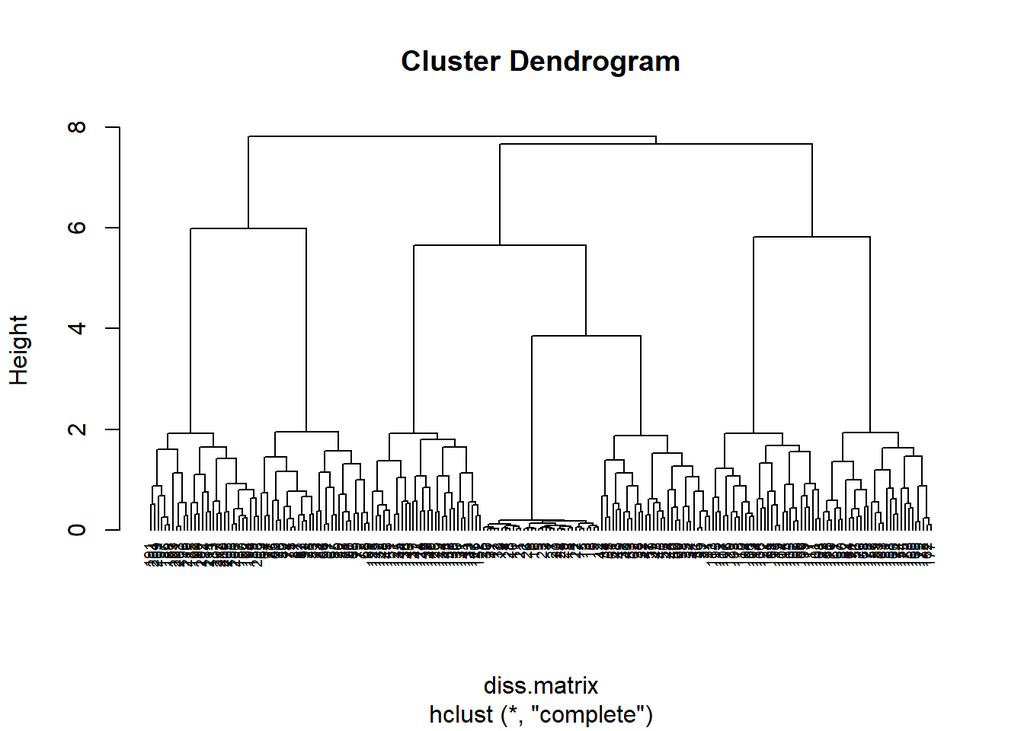

```r
# Create Dissimilarity matrix
diss.matrix <- dist(copd.data.nomiss, method = "euclidean")

# Hierarchical clustering using Complete Linkage
clusters.h<- hclust(diss.matrix, method = "complete" )

# Plot the obtained dendrogram
plot(clusters.h, cex = 0.6, hang = -1)
```

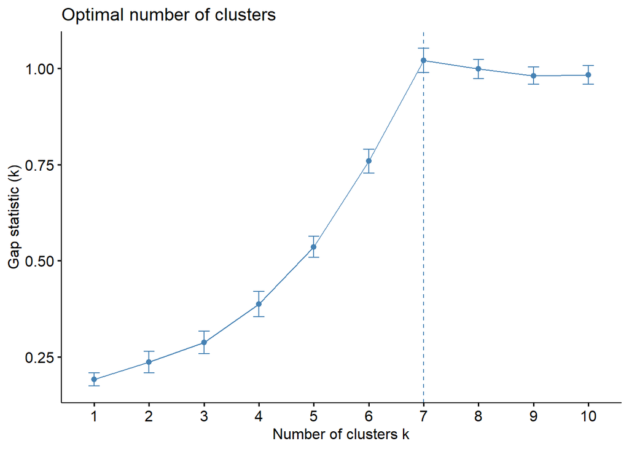

```r
#create function to use within clusGap
hclusCut <- function(x, k) list(cluster = cutree(hclust(dist(x, method="euclidian"), method="average"), k=k))

gap_stat <- clusGap(copd.data.nomiss, FUN = hclusCut, K.max = 10, B = 50)
fviz_gap_stat(gap_stat)
```

```r
#Use number of clusters from gap statistic to obtain cluster assignment for each observation
clusters.h.7<-cutree(clusters.h, k=7)
table(clusters.h.7)
```

```
## clusters.h.7
##  1  2  3  4  5  6  7
## 32 30 30 30 30 30 30
```

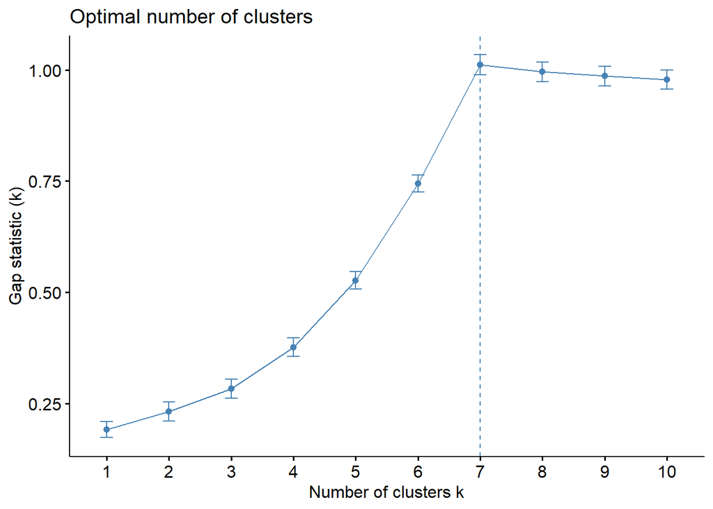

```r
#Code using default hierarchical function within clusGap
gap_stat <- clusGap(copd.data.nomiss, FUN = hcut, nstart = 25, K.max = 10, B = 50)
fviz_gap_stat(gap_stat)
```